#### 1 - Partisan ties and resource allocation in Ghana [13 points in total]

Do constituencies in Ghana that elect MPs who are from the same party as the President (the ruling party) receive more electrification over the next four years? Use the dataset `GhanaRD.csv` to find out. Here is a short description of the data:

- *constit:* constituency
- *voteshare:* vote share of MP from ruling party in a constituency
- *treatment:* elected MP from from rulinng party
- *changeNL_1996_2000:* change in electrification from 1996 - 2000 measured using nightlight emissions
- *mean_1995:* electrification in 1995
1. Does it make sense to employ a sharp RD in this case? Provide a visual check and a brief interpretation of what you see! [2 pts]

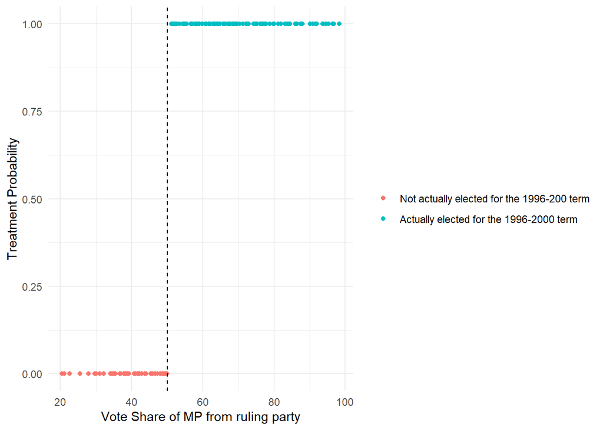

```r
Ghana <- read.csv("Ghana_RD.csv")

ggplot(Ghana, aes(x = voteshare,
                 y = treatment,
                 color = factor(treatment))) +
  geom_point() +
  labs(x = "Vote Share of MP from ruling party",
       y = "Treatment Probability") +
  scale_color_discrete(name = " ",
                       labels = c("Not actually elected for the 1996-200 term" , "Actually elected for the 1996-2000 term")) +
  geom_vline(xintercept = 50,linetype="dashed") +
  theme_minimal()
```

We can see from the graph that at 50% Vote share, candidates are elected to serve term in parliament,making voteshare in 1996 a viable forcing variable for a sharp-RDD set-up.

2. Choose a bandwidth that seems reasonable to you, cut down the dataset to the discontinuity sample, and then estimate the LATE at the threshold using a linear model with common slopes for treated and control units within the bandwidth. Provide a plot in which you show the fitted curves and the underlying scatterplot of the data. Interpret your estimate. [4 pts]

```r
# Chosen  bandiwidth: interval centered around the cutoff, with the length of the Imbens-Kalyanamaran optimal bandwidth.
#Running linear model with common slopes
new_voteshare<- Ghana %>% filter(between(voteshare, 50-IKbandwidth(Ghana$voteshare, Ghana$changeNL_1996_200, cutpoint = 50), 50+IKbandwidth(Ghana$voteshare, Ghana$changeNL_1996_200, cutpoint = 50)))
new_voteshare$forcing <- new_voteshare$voteshare-50

linear_common_slope <- lm(changeNL_1996_2000~ treatment + forcing, data = new_voteshare)
summary(linear_common_slope)
```

```
##
## Call:
## lm(formula = changeNL_1996_2000 ~ treatment + forcing, data = new_voteshare)
##
## Residuals:
##     Min      1Q  Median      3Q     Max
## -0.5495 -0.3308 -0.1848  0.3093  1.7218
##
## Coefficients:
##             Estimate Std. Error t value Pr(>|t|)
## (Intercept)  0.55494    0.20379   2.723   0.0114 *
## treatment   -0.09419    0.40114  -0.235   0.8162
## forcing     -0.02278    0.05331  -0.427   0.6726
## ---
## Signif. codes:  0 '***' 0.001 '**' 0.01 '*' 0.05 '.' 0.1 ' ' 1
##
## Residual standard error: 0.5482 on 26 degrees of freedom
## Multiple R-squared:  0.05603,    Adjusted R-squared:  -0.01659
## F-statistic: 0.7716 on 2 and 26 DF,  p-value: 0.4726
```

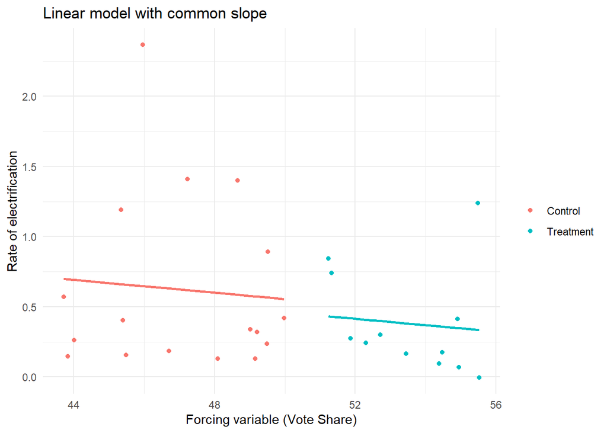

```r
#Plotting estimates
new_voteshare$yhat_linear <- predict(linear_common_slope)

linear_plot <- new_voteshare %>%
  ggplot(aes(x = voteshare,
             y = yhat_linear,
             col = factor(treatment))) +
  geom_point(aes(x = voteshare,
                 y = changeNL_1996_2000,
                 col = factor(treatment))) +
  labs(title = "Linear model with common slope",
       x = "Forcing variable (Vote Share)",
       y = "Rate of electrification") +
  geom_line(data = new_voteshare[new_voteshare$voteshare >= 50,],
            color = "#00BFC4",
            size = 1) +
  geom_line(data = new_voteshare[new_voteshare$voteshare < 50,],
            color = "#F8766D",
            size = 1) +
  scale_color_manual(name = "",
                     values = c("#F8766D", "#00BFC4"),
                     labels = c("Control", "Treatment")) +
  theme_minimal()

linear_plot
```

From the regression , LATE is -0.094. At the given threshhold, there is a reduction in rate of electrification by of 0.094. Also, for every unit increase in voting share, there is further decrease in electrification rates by 0.02278

3. Conduct the same analysis as in part (b) except that you now use a quadratic model with different model coefficients for the treated and control groups! [2 pts]

```r
#Quadratic model

quadratic <- lm(changeNL_1996_2000 ~ forcing +
                  I(forcing^2) + # I tells R to interpret "as is"
                  treatment +
                  I(forcing * treatment) +
                  I((forcing^2) * treatment),
                data = new_voteshare)
summary(quadratic)
```

```
##
## Call:
## lm(formula = changeNL_1996_2000 ~ forcing + I(forcing^2) + treatment +
##     I(forcing * treatment) + I((forcing^2) * treatment), data = new_voteshare)
##
## Residuals:
##      Min       1Q   Median       3Q      Max
## -0.75651 -0.24883 -0.03694  0.19344  1.46954
##
## Coefficients:
##                            Estimate Std. Error t value Pr(>|t|)
## (Intercept)                 0.21586    0.29745   0.726   0.4753
## forcing                    -0.44726    0.25059  -1.785   0.0875 .
## I(forcing^2)               -0.06881    0.03862  -1.782   0.0880 .
## treatment                   1.50731    0.97945   1.539   0.1375
## I(forcing * treatment)     -0.47631    0.68962  -0.691   0.4967
## I((forcing^2) * treatment)  0.19809    0.10133   1.955   0.0629 .
## ---
## Signif. codes:  0 '***' 0.001 '**' 0.01 '*' 0.05 '.' 0.1 ' ' 1
##
## Residual standard error: 0.5268 on 23 degrees of freedom
## Multiple R-squared:  0.2291, Adjusted R-squared:  0.06154
## F-statistic: 1.367 on 5 and 23 DF,  p-value: 0.2729
```

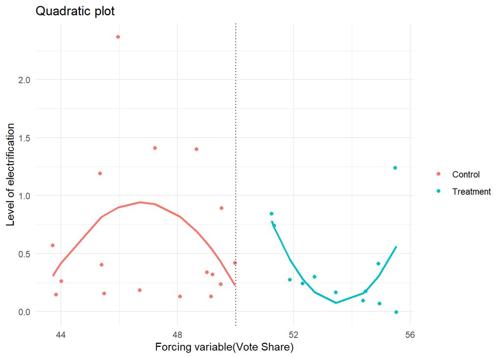

```r
#Plot
new_voteshare$yhat_quadratic <- predict(quadratic)

quadratic_plot <- new_voteshare %>%
  ggplot(aes(x = voteshare,
             y = yhat_quadratic,
             col = factor(treatment))) +
  geom_point(aes(x = voteshare,
                 y = changeNL_1996_2000,
                 col = factor(treatment))) +
  labs(title = "Quadratic plot",
       x = "Forcing variable(Vote Share)",
       y = "Level of electrification") +
  geom_line(data = new_voteshare[new_voteshare$voteshare >= 50,],
            color = "#00BFC4",
            size = 1) +
  geom_line(data = new_voteshare[new_voteshare$voteshare < 50,],
            color = "#F8766D",
            size = 1) +
  scale_color_manual(name = "",
                     values = c("#F8766D", "#00BFC4"),
                     labels = c("Control", "Treatment")) +
  geom_vline(xintercept = 50, linetype = "dotted")+
  theme_minimal()

quadratic_plot
```

At given τ we can expect an increase of 1.5 in the rate of electrification for those who were elected at threshhold

4. Now estimate the LATE at the threshold using a local linear regression with a triangular kernel. Also, use the Imbens-Kalyanamaran optimal bandwidth calculation. [3 pts]

```r
llr <- RDestimate(changeNL_1996_2000 ~ voteshare, data = new_voteshare,cutpoint = 50)
summary(llr)
```

```
##
## Call:
## RDestimate(formula = changeNL_1996_2000 ~ voteshare, data = new_voteshare,
##     cutpoint = 50)
##
## Type:
## sharp
##
## Estimates:
##            Bandwidth  Observations  Estimate  Std. Error  z value
## LATE       3.541      16            0.9133    0.2282      4.0023
## Half-BW    1.771       9            1.8203    0.2055      8.8575
## Double-BW  7.082      29            0.2130    0.2678      0.7952
##            Pr(>|z|)
## LATE       6.273e-05  ***
## Half-BW    8.180e-19  ***
## Double-BW  4.265e-01
## ---
## Signif. codes:  0 '***' 0.001 '**' 0.01 '*' 0.05 '.' 0.1 ' ' 1
##
## F-statistics:
##            F       Num. DoF  Denom. DoF  p
## LATE       0.7404  3         12          0.9038
## Half-BW    0.2519  3          5          0.2858
## Double-BW  0.9653  3         25          0.8491
```

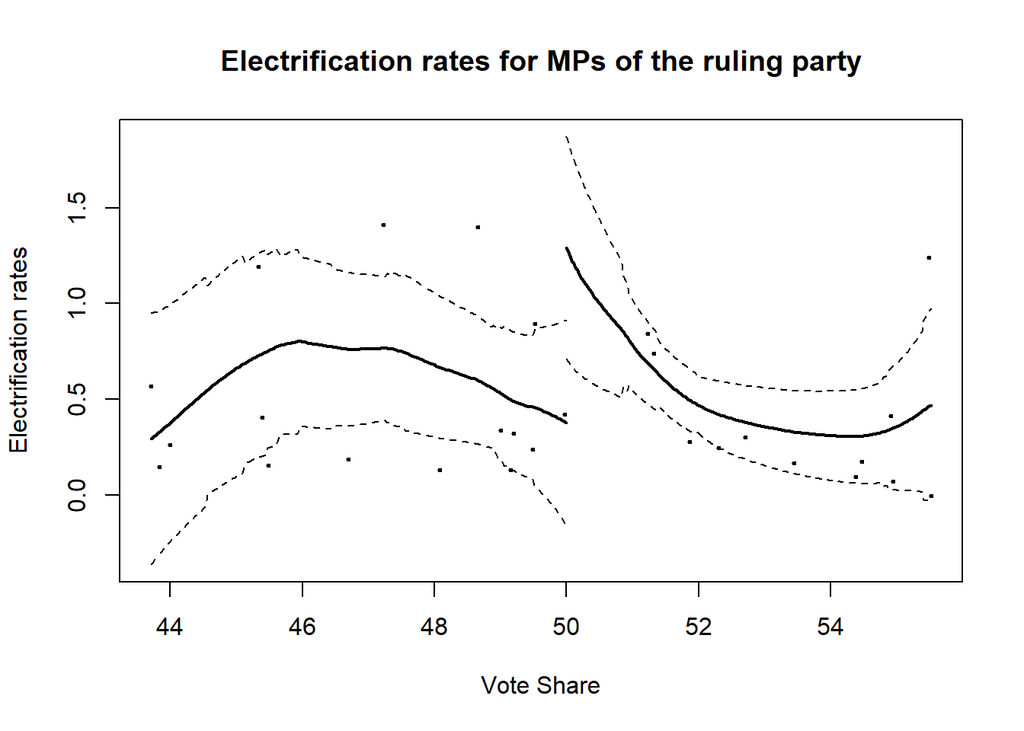

```r
plot(llr)
title(main = "Electrification rates for MPs of the ruling party", xlab = "Vote Share",ylab = "Electrification rates")
```

5. Going over the estimation results again, how robust are they to different specifications of the regression? What other types of robustness checks might be appropriate? [2 pts]

From LATE we can expect that above threshhold level, there is 0.9133 higher level of electrification for people that were elected. This result is statistically significant compared to previous LATE

#### 2 - Effects of a pre- and post-natal health care policy [12 points in total]

The dataset `hospitals.dta` provides data collected on women who gave birth at any one of several hospitals in disadvantaged neighborhoods in New York. You will use these data to evaluate the effect of a government policy that makes available pre- and post-natal health care for pregnant women, new mothers, and their children, who meet certain income eligibility requirements. To receive services, the income of these women has to have been below $20,000 at the time they gave birth. The general question of interest is whether this program increases a measure of child health at age 3.

1. Create a scatterplot of reported income versus health status. Plot treated observations in red and controls in blue. [2 pts]

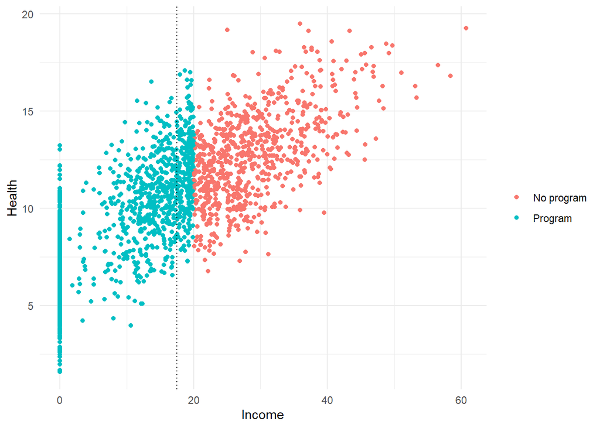

```r
hospitals <- read_dta("hospitals.dta")
ggplot(hospitals,
       aes(x = incomeR,
           y = health,
           color = factor(program))) +
  geom_point() +
  labs(x = "Income",
       y = "Health") +
  scale_color_discrete(name = " ",
                       labels = c("No program", "Program")) +
  geom_vline(xintercept = median(hospitals$incomeR), linetype = "dotted") +
  theme_minimal()
```

2. Calculate a naïve estimate of the effect of the program by running a regression of health on the indicator for program participation. What’s the estimate, and why is it naïve? [2 pts]

```r
naive <- lm(health ~ program, data = hospitals)
summary(naive)
```

```
##
## Call:
## lm(formula = health ~ program, data = hospitals)
##
## Residuals:
##     Min      1Q  Median      3Q     Max
## -7.7025 -1.9139 -0.0094  1.8482  7.8144
##
## Coefficients:
##             Estimate Std. Error t value Pr(>|t|)
## (Intercept) 12.81279    0.09834   130.3   <2e-16 ***
## program     -3.53584    0.12365   -28.6   <2e-16 ***
## ---
## Signif. codes:  0 '***' 0.001 '**' 0.01 '*' 0.05 '.' 0.1 ' ' 1
##
## Residual standard error: 2.666 on 1998 degrees of freedom
## Multiple R-squared:  0.2904, Adjusted R-squared:  0.2901
## F-statistic: 817.7 on 1 and 1998 DF,  p-value: < 2.2e-16
```

Estimate: -3.53584.Naive because assumes a single effect between treatment in control.

3. Make yourself familiar with LOESS smoothing in R and plot overlaid LOESS curves (one for each program group) of this relationship to explore whether or not the relationship between reported income and health appears to be non-linear. [2 pts]

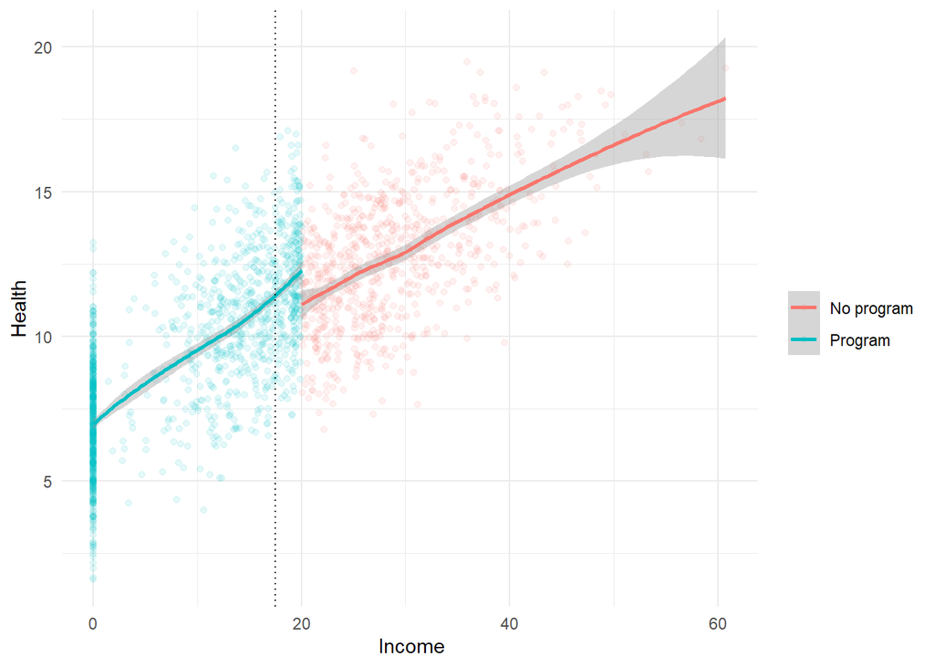

```r
  ggplot(hospitals,
       aes(x = incomeR,
           y = health,
           color = factor(program))) +
  geom_point(alpha = 0.1) +
  labs(x = " Income",
       y = "Health") +
  geom_smooth(method = "loess") +
  scale_color_discrete(name = " ",
                       labels = c("No program", "Program")) +
  geom_vline(xintercept = median(hospitals$incomeR), linetype = "dotted") +
  theme_minimal()
```

From the plot it is evident that relation between Income and Healyh is Linear

4. Now fit an RD model of your choice and report and interpret its estimates. [2 pts]

```r
RDmodel<- RDestimate(health ~ incomeR, data = hospitals, cutpoint = median(hospitals$incomeR))
summary(RDmodel)
```

```
##
## Call:
## RDestimate(formula = health ~ incomeR, data = hospitals, cutpoint = median(hospitals$incomeR))
##
## Type:
## sharp
##
## Estimates:
##            Bandwidth  Observations  Estimate  Std. Error  z value
## LATE       4.244      612           0.5269    0.3529      1.4933
## Half-BW    2.122      350           0.2127    0.4589      0.4634
## Double-BW  8.487      985           0.5530    0.2543      2.1749
##            Pr(>|z|)
## LATE       0.13536
## Half-BW    0.64306
## Double-BW  0.02964   *
## ---
## Signif. codes:  0 '***' 0.001 '**' 0.01 '*' 0.05 '.' 0.1 ' ' 1
##
## F-statistics:
##            F       Num. DoF  Denom. DoF  p
## LATE       11.253  3         608         6.825e-07
## Half-BW     4.166  3         346         1.287e-02
## Double-BW  31.763  3         981         0.000e+00
```

5. A colleague now points out to you that some women may have incentives in these settings to misreport their actual income. Plot a histogram of reported income and look for anything that might support or refute such a claim. What assumption is called into question if women are truly misreporting in this manner? [2 pts]

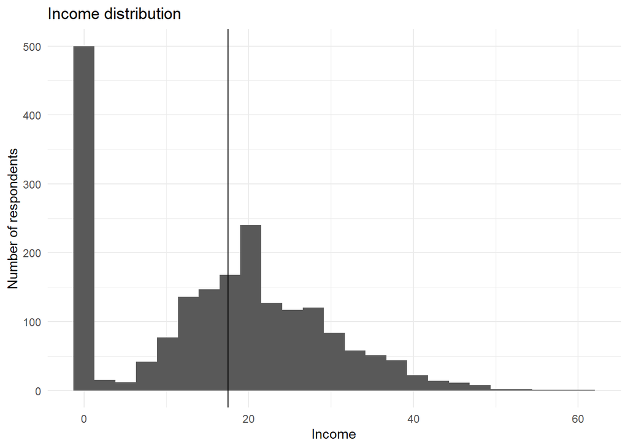

```r
ggplot(hospitals,
       aes(x = incomeR)) +
  geom_histogram(bins = 25) +
  labs(title = "Income distribution",
       x = "Income",
       y = "Number of respondents") +
  geom_vline(xintercept = median(hospitals$incomeR)) +
  theme_minimal()
```

Since theere exists a large number of respondents away from cut off at zero lveles of income, the chances are more that they are not included in the labour force. For identification of threshhold causal effect we assume Continuity of average potential outcomes E(Yi(d)∣Xi = x) is continuous in x around Xi = c for d = 0, 1. however here if there is a probability of sorting by respondents to maneuver around threshhold this will be violated

6. Another colleague points out to you that several other government programs (including food stamps etc.) have the same income threshold for eligibility. How might this knowledge impact your interpretation of your results? [2 pt]

In case of existance of same threshhold for mutiple programs, it will be difficult to analyse the unique effect of the program, leading to existence of confounder and hence omitted variable bias.